# Lab 1

# Part 1 - linear model

```r
load("Data/Pb_mossa.rda")
summary(Pb_mossa)
```

```
      year            Pb                     loc
 Min.   :1975   Min.   : 0.400   Orebro        : 85
 1st Qu.:1990   1st Qu.: 1.700   Jamtland      :224
 Median :2000   Median : 3.200   Norrbotten    :523
 Mean   :1997   Mean   : 5.819   Vasternorrland:131
 3rd Qu.:2005   3rd Qu.: 7.100   VastraGotaland:268
 Max.   :2010   Max.   :72.000
```

```r
head(Pb_mossa)
```

|  | year | Pb | loc |
| --- | --- | --- | --- |
| 1 | 1975 | 12.0 | Jamtland |
| 2 | 1975 | 8.1 | Jamtland |
| 3 | 1975 | 22.0 | Jamtland |
| 4 | 1975 | 23.0 | Jamtland |
| 5 | 1975 | 17.0 | Jamtland |
| 6 | 1980 | 9.3 | Jamtland |

```r
Pb_mossa$nyear = I(Pb_mossa$year-1975)
```

```r
(Pb_mossa.model <- lm(Pb ~ I(year-1975), data = Pb_mossa))
```

```
Call:
lm(formula = Pb ~ I(year - 1975), data = Pb_mossa)

Coefficients:
   (Intercept)  I(year - 1975)
       16.9625         -0.4967
```

```r
(Pb_mossa.summary <- summary(Pb_mossa.model))
```

```
Call:
lm(formula = Pb ~ I(year - 1975), data = Pb_mossa)

Residuals:
   Min     1Q Median     3Q    Max
-9.679 -2.946 -0.562  1.621 55.038

Coefficients:
               Estimate Std. Error t value Pr(>|t|)
(Intercept)    16.96249    0.38550   44.00   <2e-16 ***
I(year - 1975) -0.49668    0.01576  -31.52   <2e-16 ***
---
Signif. codes:  0 ‘***’ 0.001 ‘**’ 0.01 ‘*’ 0.05 ‘.’ 0.1 ‘ ’ 1

Residual standard error: 5.391 on 1229 degrees of freedom
Multiple R-squared:  0.447, Adjusted R-squared:  0.4466
F-statistic: 993.5 on 1 and 1229 DF,  p-value: < 2.2e-16
```

```r
(Pb_mossa.xtxinv <- Pb_mossa.summary$cov.unscaled)
```

```
                 (Intercept) I(year - 1975)
(Intercept)     0.0051136614  -1.917059e-04
I(year - 1975) -0.0001917059   8.544170e-06
```

```r
(Pb_mossa.beta.cov <- Pb_mossa.summary$sigma^2*Pb_mossa.xtxinv)
```

```
                (Intercept) I(year - 1975)
(Intercept)     0.148611650   -0.005571298
I(year - 1975) -0.005571298    0.000248308
```

```r
sqrt(diag(Pb_mossa.beta.cov))
```

```
   (Intercept) I(year - 1975)
    0.38550182     0.01575779
```

```r
Pb_mossa.summary$coefficients
```

```
                 Estimate Std. Error   t value      Pr(>|t|)
(Intercept)    16.9624942 0.38550182  44.00107 1.012959e-254
I(year - 1975) -0.4966774 0.01575779 -31.51948 2.688665e-160
```

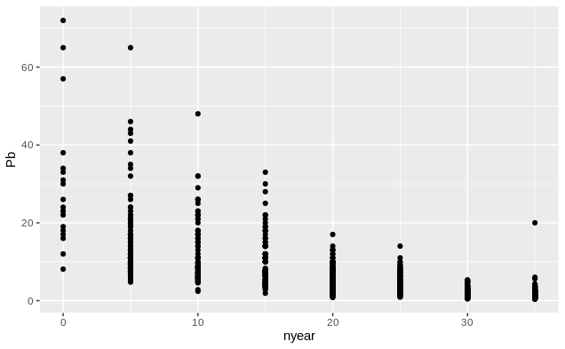

```r
library(ggplot2)
#plot(Pb_mossa$year, Pb_mossa$Pb)
ggplot(data =Pb_mossa,
           aes(x=nyear, y=Pb)) +
    geom_point()
```

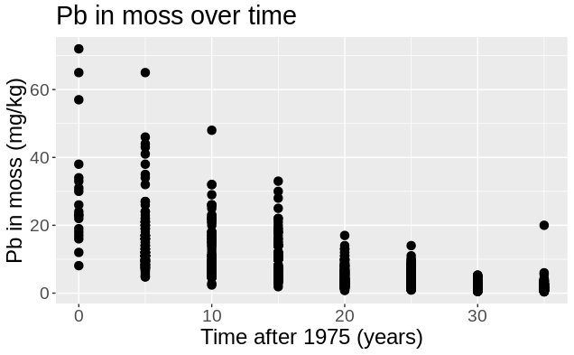

```r
(
  plot.data <-
    ggplot(data =Pb_mossa,
           aes(x=nyear, y=Pb)) +
    geom_point(size = 3) +
    xlab("Time after 1975 (years)") +
    ylab("Pb in moss (mg/kg)") +
    labs(title = "Pb in moss over time") +
    theme(text = element_text(size = 18))
)
```

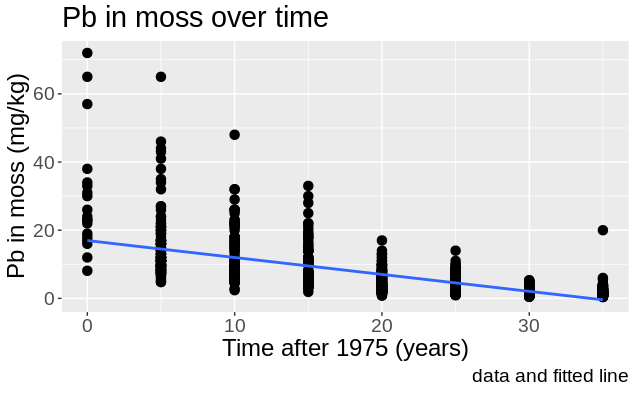

```r
(
  plot.data +
    geom_smooth(method = lm, se = FALSE) +
    labs(caption = "data and fitted line")
)
```

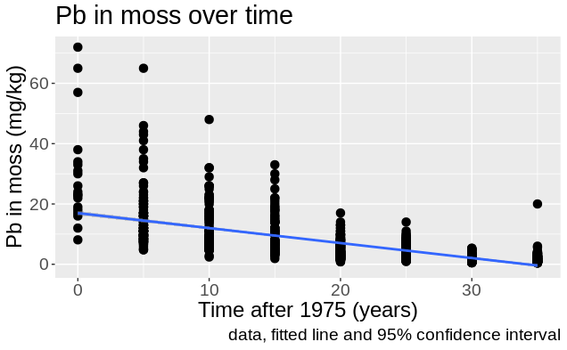

```r
(
  plot.conf <- plot.data +
    geom_smooth(method = lm) +
    labs(caption = "data, fitted line and 95% confidence interval")
)
```

```r
Pb_mossa.pred <-
  cbind(Pb_mossa,
        pred = predict(Pb_mossa.model, interval = "prediction"))
```

```
predictions on current data refer to _future_ responses
```

```r
head(Pb_mossa.pred)
```

|  | year | Pb | loc | nyear | pred.fit | pred.lwr | pred.upr |
| --- | --- | --- | --- | --- | --- | --- | --- |
| 1 | 1975 | 12.0 | Jamtland | 0 | 16.96249 | 6.359121 | 27.56587 |
| 2 | 1975 | 8.1 | Jamtland | 0 | 16.96249 | 6.359121 | 27.56587 |
| 3 | 1975 | 22.0 | Jamtland | 0 | 16.96249 | 6.359121 | 27.56587 |
| 4 | 1975 | 23.0 | Jamtland | 0 | 16.96249 | 6.359121 | 27.56587 |
| 5 | 1975 | 17.0 | Jamtland | 0 | 16.96249 | 6.359121 | 27.56587 |
| 6 | 1980 | 9.3 | Jamtland | 5 | 14.47911 | 3.884723 | 25.07349 |

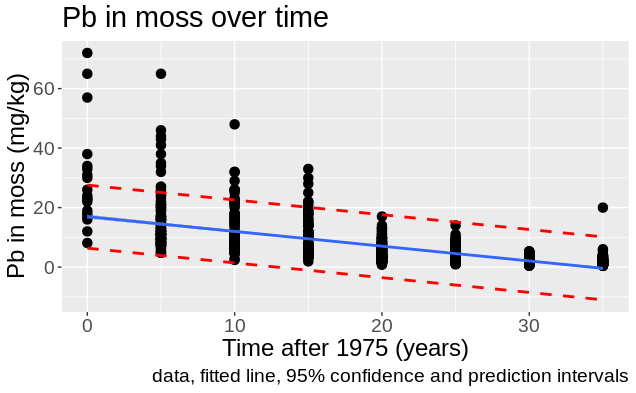

```r
(
  plot.conf +
    geom_line(data = Pb_mossa.pred, aes(y = pred.lwr),
              color = "red", linetype = "dashed", size = 1) +
    geom_line(data = Pb_mossa.pred, aes(y = pred.upr),
              color = "red", linetype = "dashed", size = 1) +
    labs(caption = "data, fitted line, 95% confidence and prediction intervals")
)
```

```r
Pb_mossa.pred$e <- Pb_mossa.model$residuals
head(Pb_mossa.pred)
```

|  | year | Pb | loc | nyear | pred.fit | pred.lwr | pred.upr | e |
| --- | --- | --- | --- | --- | --- | --- | --- | --- |
| 1 | 1975 | 12.0 | Jamtland | 0 | 16.96249 | 6.359121 | 27.56587 | -4.96249422 |
| 2 | 1975 | 8.1 | Jamtland | 0 | 16.96249 | 6.359121 | 27.56587 | -8.86249422 |
| 3 | 1975 | 22.0 | Jamtland | 0 | 16.96249 | 6.359121 | 27.56587 | 5.03750578 |
| 4 | 1975 | 23.0 | Jamtland | 0 | 16.96249 | 6.359121 | 27.56587 | 6.03750578 |
| 5 | 1975 | 17.0 | Jamtland | 0 | 16.96249 | 6.359121 | 27.56587 | 0.03750578 |
| 6 | 1980 | 9.3 | Jamtland | 5 | 14.47911 | 3.884723 | 25.07349 | -5.17910711 |

```r
(max.e <- max(abs(Pb_mossa.pred$e)))
```

```
[1] 55.03751
```

```r
(Pb_mossa.elims <- c(-max.e, max.e))
```

```
[1] -55.03751  55.03751
```

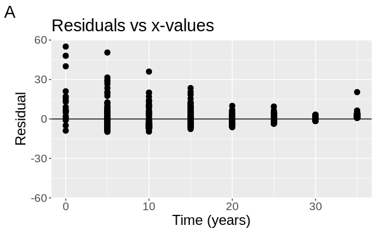

```r
ggplot(data = Pb_mossa.pred,
       aes(x = nyear, y = e)) +
  geom_point(size = 3) +
  geom_hline(yintercept = 0) +
  expand_limits(y = Pb_mossa.elims) +
  xlab("Time (years)") +
  ylab("Residual") +
  labs(tag = "A") +
  labs(title = "Residuals vs x-values") +
  theme(text = element_text(size = 18))
```

A trend can be seen where the residuals are large early and smaller later on. They don’t seem to be randomly distributed around 0 either.

```r
ggplot(data = Pb_mossa.pred,
       aes(x = pred.fit, y = e)) +
  geom_point(size = 3) +
  geom_hline(yintercept = 0) +
  expand_limits(y = Pb_mossa.elims) +
  xlab("Predicted Pb amount (mg/kg)") +
  ylab("Residual") +
  labs(tag = "B") +
  labs(title = "Residuals vs predicted values Y-hat") +
  theme(text = element_text(size = 18))
```

[output not shown]

Same problem here

```r
ggplot(data = Pb_mossa.pred,
       aes(sample = e)) +
  geom_qq(size = 3) +
  geom_qq_line() +
  labs(tag = "C") +
  labs(title = "Normal Q-Q-plot of the residuals") +
  theme(text = element_text(size = 18))
```

[output not shown]

Points should be linear all the way but grows in the end

```r
(Pb_mossa.x0 <- data.frame(year = c(2015, 2020)))

(
  Pb_mossa.y0.pred <-
    cbind(Pb_mossa.x0,
          predict(Pb_mossa.model, Pb_mossa.x0, se.fit = TRUE),
          conf = predict(Pb_mossa.model, Pb_mossa.x0,
                         interval = "confidence"),
          pred = predict(Pb_mossa.model, Pb_mossa.x0,
                         interval = "prediction"))
)

Pb_mossa.y0.pred$residual.scale <-  Pb_mossa.y0.pred$conf.fit <-
  Pb_mossa.y0.pred$pred.fit <- NULL
Pb_mossa.y0.pred

Pb_mossa.y0.pred$se.pred <-
  sqrt(Pb_mossa.summary$sigma^2 + Pb_mossa.y0.pred$se.fit^2)
```

[output not shown]

The prediction and confidence intervals are not realistic since some of the values are negative. Especially the confidence interval which has a negative upper bound.

# Part 2 - log transformation

```r
library(ggplot2)
Pb_log = Pb_mossa
Pb_log$Pb <- log(Pb_mossa$Pb)
Pb_log$nyear <- Pb_mossa$nyear

Pb_log
```

[output not shown]

```r
ggplot(data =Pb_log,
           aes(x=nyear, y=Pb)) +
    geom_point()
(
  plot.data <-
    ggplot(data =Pb_log,
           aes(x=nyear, y=Pb)) +
    geom_point(size = 3) +
    xlab("Time after 1975 (years)") +
    ylab("Pb in moss (mg/kg)") +
    labs(title = "Pb in moss over time") +
    theme(text = element_text(size = 18))
)
```

[output not shown]

```r
(
  plot.data +
    geom_smooth(method = lm, se = FALSE) +
    labs(caption = "data and fitted line")
)

(Pb_log.model <- lm(Pb ~ nyear, data = Pb_log))
(Pb_log.summary <- summary(Pb_log.model))

Pb_log.pred <-
  cbind(Pb_log,
        pred = predict(Pb_log.model, interval = "prediction"))
head(Pb_log.pred)

(
  plot.conf <- plot.data +
    geom_smooth(method = lm) +
    labs(caption = "data, fitted line and 95% confidence interval")
)
(
  plot.conf +
    geom_line(data = Pb_log.pred, aes(y = pred.lwr),
              color = "red", linetype = "dashed", size = 1) +
    geom_line(data = Pb_log.pred, aes(y = pred.upr),
              color = "red", linetype = "dashed", size = 1) +
    labs(caption = "data, fitted line, 95% confidence and prediction intervals")
)
```

[output not shown]

This fit looks a lot better!

```r
Pb_log.pred$e <- Pb_log.model$residuals
head(Pb_log.pred)

(max.e <- max(abs(Pb_log.pred$e)))
(Pb_log.elims <- c(-max.e, max.e))
```

[output not shown]

```r
ggplot(data = Pb_log.pred,
       aes(x = nyear, y = e)) +
  geom_point(size = 3) +
  geom_hline(yintercept = 0) +
  expand_limits(y = Pb_log.elims) +
  xlab("Time (years)") +
  ylab("Residual") +
  labs(tag = "A") +
  labs(title = "Residuals vs x-values") +
  theme(text = element_text(size = 18))
```

[output not shown]

The values look distributed evenly around 0 which is promising

```r
ggplot(data = Pb_log.pred,
       aes(x = pred.fit, y = e)) +
  geom_point(size = 3) +
  geom_hline(yintercept = 0) +
  expand_limits(y = Pb_log.elims) +
  xlab("Predicted Pb amount (mg/kg)") +
  ylab("Residual") +
  labs(tag = "B") +
  labs(title = "Residuals vs predicted values Y-hat") +
  theme(text = element_text(size = 18))
```

[output not shown]

These also look evenly distributed around 0.

```r
ggplot(data = Pb_log.pred,
       aes(sample = e)) +
  geom_qq(size = 3) +
  geom_qq_line() +
  labs(tag = "C") +
  labs(title = "Normal Q-Q-plot of the residuals") +
  theme(text = element_text(size = 18))
```

[output not shown]

Looks quite good. The fit seems to be a bit off due to the top right point being more off than the others.

```r
(Pb_log.x0 <- data.frame(nyear = c(2015-1975, 2020-1975)))

(
  Pb_log.y0.pred <-
    cbind(Pb_log.x0,
          predict(Pb_log.model, Pb_log.x0, se.fit = TRUE),
          conf = predict(Pb_log.model, Pb_log.x0,
                         interval = "confidence"),
          pred = predict(Pb_log.model, Pb_log.x0,
                         interval = "prediction"))
)

Pb_log.y0.pred$residual.scale <- Pb_log.y0.pred$conf.fit <-
  Pb_log.y0.pred$pred.fit <- NULL
Pb_log.y0.pred

Pb_log.y0.pred$se.pred <-
  sqrt(Pb_log.summary$sigma^2 + Pb_log.y0.pred$se.fit^2)
```

[output not shown]

The intervals look better but are still slightly negative. This is likely due to the last point in the QQ-plot being very off.

# Part 3 - transforming back

```r
Pb_log.b0 = Pb_log.summary$coefficients[1]
Pb_log.b1 = Pb_log.summary$coefficients[2]
Pb_log.a = exp(Pb_log.b0)
Pb_log.b = exp(Pb_log.b1)
Pb_log.Ia = exp(confint(Pb_log.model)[1,])
Pb_log.Ib = exp(confint(Pb_log.model)[2,])
```

```r
Pb_log.a + Pb_log.b
```

[output not shown]

which seems reasonable by visually inspecting the graph over the concentration. Since b = 0.92 the decrease should be 1-0.92 = 0.08 (8%) each year.

```r
(
  plot.data <-
    ggplot(data =Pb_mossa,
           aes(x=nyear, y=Pb)) +
    geom_point(size = 3) +
    xlab("Time after 1975 (years)") +
    ylab("Pb in moss (mg/kg)") +
    labs(title = "Pb in moss over time") +
    theme(text = element_text(size = 18))
)

Pb_log.pred <-
  cbind(Pb_log,
        fit = predict(Pb_log.model),
        conf = predict(Pb_log.model,
                          interval = "confidence"),
        pred = predict(Pb_log.model,
                          interval = "prediction"))
head(Pb_log.pred)
(
  plot.pred <- plot.data +
    geom_line(data = Pb_log.pred,
              aes(y = exp(fit)),
              color = "blue", size = 1) +
    geom_ribbon(data = Pb_log.pred,
                aes(ymin = exp(conf.lwr),
                ymax = exp(conf.upr)),
                alpha = 0.2) +
    geom_line(data = Pb_log.pred,
              aes(y = exp(pred.lwr)),
              color = "red", linetype = "dashed",
              size = 1) +
    geom_line(data = Pb_log.pred,
              aes(y = exp(pred.upr)),
              color = "red", linetype = "dashed",
              size = 1) +
    labs(caption = "fitted line and 95% conf. and pred. intervals")
)


plot.data <-
  ggplot(data =Pb_mossa,
         aes(x=year, y=Pb)) +
  geom_point(size = 3) +
  xlab("Year") +
  ylab("Pb in moss (mg/kg)") +
  labs(title = "Pb in moss over time") +
  theme(text = element_text(size = 18))


(
  plot.pred <- plot.data +
    geom_line(data = Pb_log.pred,
              aes(y = exp(fit)),
              color = "blue", size = 1) +
    geom_ribbon(data = Pb_log.pred,
                aes(ymin = exp(conf.lwr),
                ymax = exp(conf.upr)),
                alpha = 0.2) +
    geom_line(data = Pb_log.pred,
              aes(y = exp(pred.lwr)),
              color = "red", linetype = "dashed",
              size = 1) +
    geom_line(data = Pb_log.pred,
              aes(y = exp(pred.upr)),
              color = "red", linetype = "dashed",
              size = 1) +
    labs(caption = "fitted line and 95% conf. and pred. intervals")
)
```

[output not shown]

Looks to fit the data much better than the linear fit

```r
(Pb_log.x0 <- data.frame(nyear = c(2015-1975, 2020-1975)))

(
  Pb_log.y0.pred <-
    cbind(Pb_log.x0,
          predict(Pb_log.model, Pb_log.x0, se.fit = TRUE),
          conf = predict(Pb_log.model, Pb_log.x0,
                         interval = "confidence"),
          pred = predict(Pb_log.model, Pb_log.x0,
                         interval = "prediction"))
)

Pb_log.y0.pred$residual.scale <- Pb_log.y0.pred$conf.fit <-
  Pb_log.y0.pred$pred.fit <- NULL
Pb_log.y0.pred

Pb_log.y0.pred$se.pred <-
  sqrt(Pb_log.summary$sigma^2 + Pb_log.y0.pred$se.fit^2)
```

[output not shown]

```r
Pb_log.y0exp.pred = exp(Pb_log.y0.pred)
Pb_log.y0exp.pred$nyear = Pb_log.y0.pred$nyear

Pb_log.y0exp.pred
```

[output not shown]

The confidence and prediction intervals seem reasonable since they contain no negative values and are small.